# **Goal Programming**

Andrew Johns

## Objective

This study is show an overview of Goal Programming using data from a company with three goals to achieve in terms of “Long-run profit”, “Employment level”, and “Capital Investment.”

In the next examples, both Nonpreemptive Goal Programming (Goals with similar importance) and Preemptive Goal Programming (Goals with different priority levels) minimization models are built.

### Nonpreemptive Approach

Below is the table of data used for the Nonpreemptive example. Based off this, our model will have 9 decision variables as each product with have a long-run profit, employment level, and capital investment along with 3 constraints relating to the goal (unit) section. Auxiliary varables are added to help express the penalty weight mathematically in the objective function and constraints.

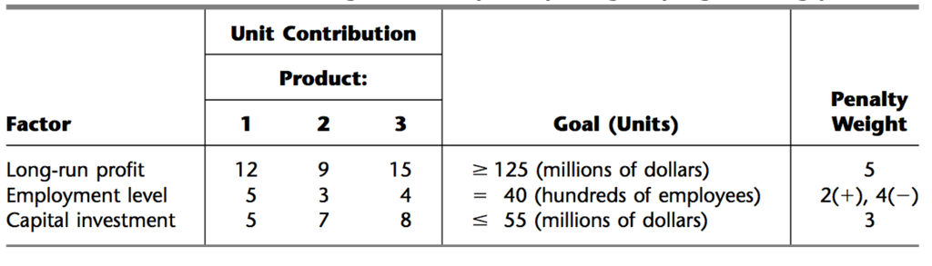

```r
library(lpSolveAPI)
x <- read.lp("Goal.lp")
solve(x)
```

```
## [1] 0
```

```r
get.objective(x)
```

```
## [1] 16.66667
```

```r
get.variables(x)
```

```
## [1] 0.000000 8.333333 0.000000 0.000000 8.333333 0.000000 1.666667 0.000000
## [9] 0.000000
```

#### Results

This shows a bump in the workforce with employment rising by roughly 8.

### Preemptive Approach

In this example, a high priority is placed on not increasing the employment level and keeping the capital investment at or below the 55 million described in the goals. This can be accomplished by creating a streamlined model using big M values on the two variables to ensure they are not adjusted. The priority levels are described below:

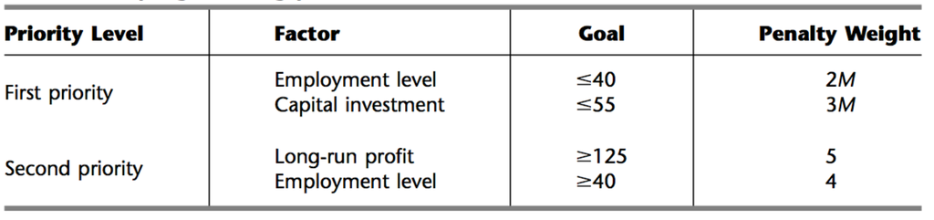

```r
x <- read.lp("Streamlined.lp")
x
```

```
## Model name:
##   a linear program with 9 decision variables and 3 constraints
```

```r
solve(x)
```

```
## [1] 0
```

```r
get.objective(x)
```

```
## [1] 48.75
```

```r
get.variables(x)
```

```
## [1] 8.75 0.00 0.00 0.00 5.00 0.00 3.75 0.00 0.00
```